# PL4246 Preliminary Report

Dataset: [3, social network]

Name: Reynard Cheng

Tutorial Group: W2

# Section 1: R Code

Instructions: Provide R code that (i) generates the network object and (ii) the macro-level network analysis results discussed in the write-up below.

## Network construction

```r
# enter your code here, feel free to use multiple R code chunks


## reading the data files
responses = read.csv('AY26Sem1/class-responses_AY26Sem1.csv', header = T)
node_info = read.csv('AY26Sem1/class-names_AY26Sem1.csv', header = T)


responses_dw = graph_from_data_frame(responses, directed = T, vertices = node_info)
summary(responses_dw)
```

```
## IGRAPH e801439 DNW- 59 652 --
## + attr: name (v/c), gender (v/c), year_of_study (v/n), ethnicity (v/c),
## | HM_or_not (v/c), weight (e/n)
```

```r
## assigning ids node attribute to the network
## comparing nodes to of nodeinfo to network
nrow(node_info) == vcount(responses_dw) # comparing number of vertices
```

```
## [1] TRUE
```

```r
identical(node_info$id, V(responses_dw)$name) #overall comparison
```

```
## [1] TRUE
```

```r
setdiff(responses$rater, node_info$id) # check if there are different or missing ids
```

```
## character(0)
```

```r
anyDuplicated(node_info$id) # check for duplicates
```

```
## [1] 0
```

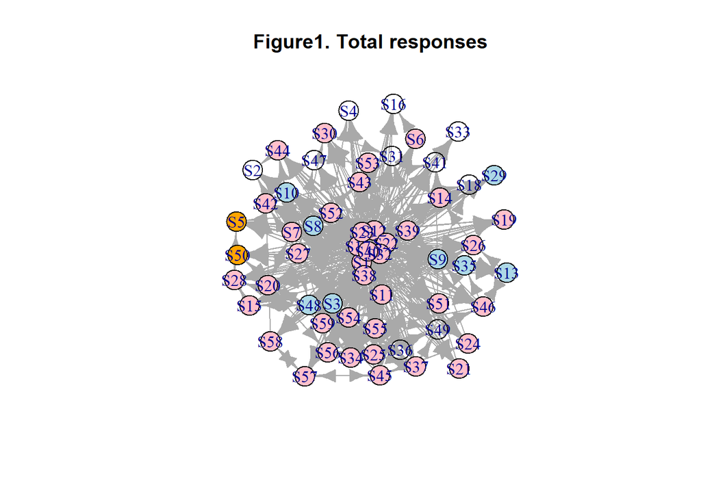

```r
plot(responses_dw,vertex.color = gender_colors, main = "Figure1. Total responses")
```

```r
## friends are people with relationsip
friends = subgraph_from_edges(responses_dw,
                                    eids = E(responses_dw)[E(responses_dw)$weight >=3]
                                    , delete.vertices = T)
## checking if the relatioship is mutual
mutual_friends = subgraph_from_edges(
  friends,
  eids = E(friends)[which_mutual(friends)],
  delete.vertices = TRUE
)
```

```r
## Connections greater than 3 are counted as close friends
close_friends = subgraph_from_edges(responses_dw,
                              eids = E(responses_dw)[E(responses_dw)$weight >3]
                              , delete.vertices = T)

mutual_close = subgraph_from_edges(
  close_friends,
  eids = E(close_friends)[which_mutual(close_friends)],
  delete.vertices = TRUE
)
```

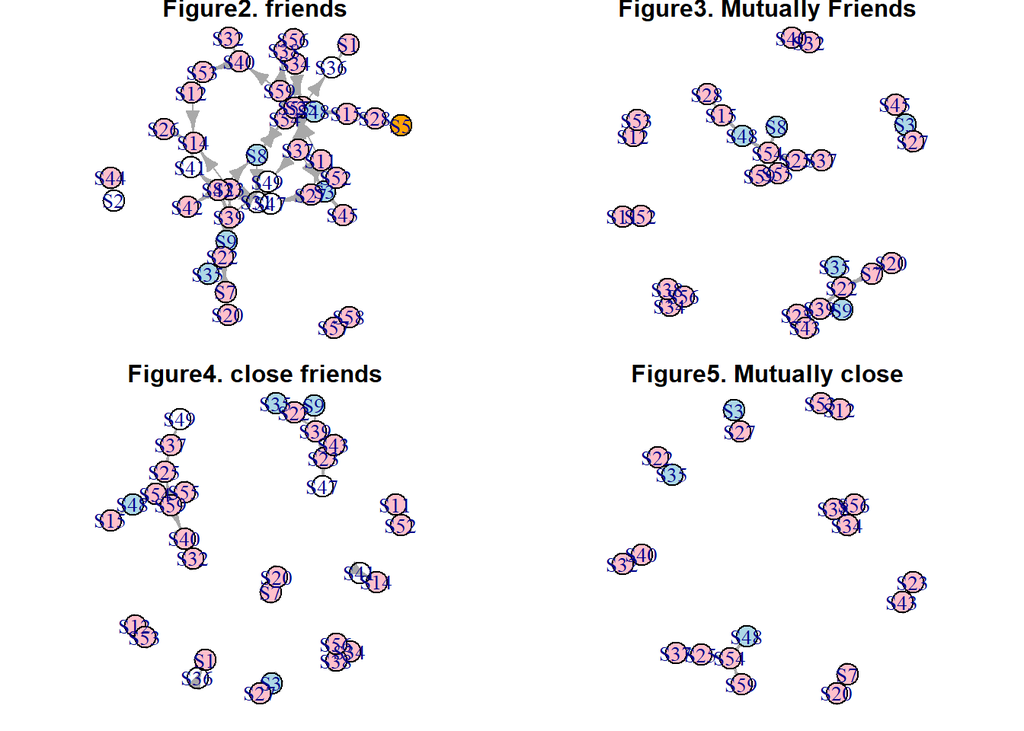

```r
par(mar=c(0,0,0,0)+.6, mfrow = c(2,2))
######## plotting graphs ###########

plot(friends,vertex.color = gender_friends,edge.arrow.size = 0.7, main = "Figure2. friends")
plot(mutual_friends,vertex.color = gender_mutual,edge.arrow.size = 0.7, main = "Figure3. Mutually Friends")
plot(close_friends, vertex.color = gender_close,edge.arrow.size = 0.7, main = "Figure4. close friends")
plot(mutual_close,vertex.color = gender_mutualclose,edge.arrow.size = 0.7, main = "Figure5. Mutually close")
```

## Macro-level network analysis

```r
# enter your code here, feel free to use multiple R code chunks
## average connection weight
E(responses_dw)$weight |> summary()
```

```
##    Min. 1st Qu.  Median    Mean 3rd Qu.    Max.
##   1.000   1.000   1.000   1.416   1.000   5.000
```

```r
reciprocity(responses_dw)
```

```
## [1] 0.2944785
```

```r
##### Network density #####
edge_density(responses_dw)
```

```
## [1] 0.1905319
```

```r
##### Average Degree #####
mean(degree(responses_dw, mode = "in"))
```

```
## [1] 11.05085
```

```r
mean(degree(responses_dw, mode = "out"))
```

```
## [1] 11.05085
```

```r
##### clustering #####
transitivity(responses_dw, type = "global")
```

```
## [1] 0.4343719
```

```r
transitivity(responses_dw, type = "local") |> mean()
```

```
## [1] 0.8314946
```

```r
##### Diameter #####
##### Average path length #####
mean_distance(responses_dw)
```

```
## [1] 3.17288
```

```r
diameter(responses_dw)
```

```
## [1] 8
```

```r
##### Assortative mixing #####

# Degree assortativity
assortativity_degree(
  responses_dw,
  directed = TRUE
)
```

```
## [1] -0.3319795
```

```r
# Gender assortativity
gender <- V(responses_dw)$gender

# Treat missing gender as "No Response"
gender[is.na(gender)] <- "No Response"

# Convert categories to integer IDs
gender_type <- as.integer(factor(gender))

assortativity_nominal(
  responses_dw,
  types = gender_type,
  directed = TRUE
)
```

```
## [1] 0.00456139
```

```r
##### Small world index #####
responses_uu = graph_from_data_frame(responses, directed = F, vertices = node_info)
summary(responses_uu)
```

```
## IGRAPH e8577a2 UNW- 59 652 --
## + attr: name (v/c), gender (v/c), year_of_study (v/n), ethnicity (v/c),
## | HM_or_not (v/c), weight (e/n)
```

```r
responses_uu <- delete_edge_attr(
  responses_uu,
  "weight"
)
summary(responses_uu)
```

```
## IGRAPH e8577a2 UN-- 59 652 --
## + attr: name (v/c), gender (v/c), year_of_study (v/n), ethnicity (v/c),
## | HM_or_not (v/c)
```

```r
##making er networks
set.seed(1)

er_graphs <- list()

for(i in 1:5) { # number of networks to generate
  er_graphs[[i]] <- sample_gnm(n = gorder(responses_uu), m = gsize(responses_uu), directed = F, loops = F)
}

# compute the L and C for each ER network, take the mean
sapply(er_graphs, mean_distance) |> mean() # L_rand
```

```
## [1] 1.619053
```

```r
sapply(er_graphs, transitivity, type = 'global') |> mean() # C_rand
```

```
## [1] 0.3819406
```

```r
##calculating small world index
CiC = transitivity(responses_uu, type = "global")/sapply(er_graphs, transitivity, type = 'global') |> mean()
LiL = mean_distance(responses_uu)/sapply(er_graphs, mean_distance) |> mean()
swi = CiC/LiL
swi
```

```
## [1] 1.099261
```

# Section 2: Write-up

Instructions: In less than 1,000 words, provide (i) a description of the network/data and discussion of the implications of its macro-level structure based on the network analysis, and (ii) a proposed research topic or question or problem statement based on a brief literature review and describe how network analysis can be used to address the question.

*directly enter your text below*

(i)The network data (Figure1) is a collection of 59 responses, of which 50 completed the survey. The network is directed, consists of 59 nodes, and has 652 edges. The edge density of the responses was 0.1905, meaning that about 19% of all possible edges in the network are actual edges. Incomplete surveys or surveys with no response were still included as nodes, as they still represented students in the class and had opportunities for edges to be directed to them. Overall, the network consists of a majority of females, followed by males, then non-binary/other students. This could have an impact when considering assortative mixing by gender that will be discussed later.

Firstly, the mean edge weight is 1.416 with a median of 1, which tells us that most of the relationships in the class were on the lower end of the scale. With a reciprocity of only 29.4%, most people who thought of others as friends or close friends did not have the corresponding party feeling the same way. The average degree for each student was about 11 incoming and outgoing. This, however, could be a product of the survey, as a student may be counted as an acquaintance as long as they were in the same class.

The global transitivity of the network is 0.43, indicating that the probability of two nodes/students being connected is about 40%. The average local transitivity of the network is 0.83, indicating that if a student was connected to several other students, their connections would also be connected. The network being so connected is also shown through its Average Shortest Path Length(ASPL) of 3.17, meaning that on average it takes about 3 .17 steps to connect two randomly selected nodes, with the longest path being only 8 steps.

The network has an assortativity coefficient of -0.33, meaning that there was a tendency for a student with more connections to form ties with less-connected students. When testing for homophily by gender, it returned a result of 0.004, indicating that there is little tendency for connections to be affected by gender. Finally, the small-world index test showed a value of 1.099, which slightly exceeded the conventional threshold of 1, suggesting the presence of a small-world network structure.

(ii)Yang & Girgus (2019) conducted a meta-analysis consisting of 90 papers and 30372 participants and found that women put a higher emphasis on sociotropy. Though it may differ by culture. Lang-Takac & Osterweil (1992) operationalised separateness through self-other differentiation and independence, and connectedness through empathy and desire for intimacy. The findings suggest that women tended towards achieving greater connectedness while men tended towards separation. Previous research, such as the one above, showed that, in general, women tend to value and make more connections than men. Thus, a possible research question to tackle would be whether women are more connected than men, and whether they have more close friendships than men, either as a byproduct or in general.

The network /data allows for this exact analysis, as the surveys indicated gender and how connected they were to others. Additional data from previous years were also provided, which can be used as a comparison to the current data. Lee et al. (2002) mention that men showed that strong connectedness was associated with lower stress in both genders, with a stronger association in men.

A question then arises: if stronger connections lowered stress in men, why do they then tend toward separateness or are less connected than women? The network data could tell us about these differences, as shown in Figure 2-5. One interpretation could be that though men were less connected, the relationships they formed were usually reciprocated. This could suggest that men were more picky with their connections; it could mean that men had higher criteria for considering closeness. The network data provided allows for this analysis, as it is possible to compare and find relationships that are only reciprocal and compare how many were actually reciprocated.

Finally, with 3 different batches of network data, we can compare the data and see if there were differences in connections between men and women. Possible important analyses to answer these questions would be tests for homophily, degree, edge attributes, and transitivity. Szell & Thurner (2013) found that women had a higher degree, or more connections, compared to men. Female networks were also more clustered and had a clustering coefficient of about 25%; they also found that females displayed more homophily, whereas males displayed higher heterophily. An interesting find that was similar to the above network analysis was that females tend to have more connections, whilst males tend to be connected to others who were more connected. This finding is similar to the macro analysis above, where more connected individuals tended to connect with less connected individuals.

In conclusion, with the network data provided coupled with the network analytical methods, there is a high possibility of answering the research questions. We can test for connectedness through degree, the strength of friendships through edge weights and strength, and compare the proportion of close friendships rather than using their absolute numbers.

# References

Lang-Takac, E., & Osterweil, Z. (1992). Separateness and connectedness: Differences between the genders. Sex Roles, 27(5), 277-289.

Lee, R. M., Keough, K. A., & Sexton, J. D. (2002). Social connectedness, social appraisal, and perceived stress in college women and men. Journal of Counseling & Development, 80(3), 355-361.

Szell, M., & Thurner, S. (2013). How women organize social networks different from men. Scientific reports,, 3(1),1214.

Yang, K., & Girgus, J. S. (2019). Are women more likely than men are to care excessively about maintaining positive social relationships? A meta-analytic review of the gender difference in sociotropy. Sex Roles, 81(3), 157-172.